# Module Six Activity

# Part Two: Static Visualizations with Design Principles

#### Create multiple static visualizations using Matplotlib or Seaborn that highlight key insights from the dataset.

Consider the following examples:

- A heatmap showing correlations between variables.
- A hierarchical bar chart comparing categories and subcategories.
- A time series line chart with annotations showing trends.

*Note:* Save all these files as PNG files in the output folder to be render in html using the display() function or the show() function for the chart.

#### Apply visualization design principles.

Include the following:

- Use effective color palettes (color theory).
- Label axes, titles, and legends following typography best practices.
- Ensure proportions and scaling are appropriate for the data.
- Consider accessibility (e.g., colorblind-friendly palettes).

## Load the preprocessed dataset from Part One above

```python
df = pd.read_csv("data/COVID_total_deaths_preprocessed.csv")
print("Preprocessed dataset loaded successfully!")
df.head()
```

```
Preprocessed dataset loaded successfully!
```

|  | date | World | Afghanistan | Africa | Albania | Algeria | American Samoa | Andorra | Angola | Anguilla | ... | Uruguay | Uzbekistan | Vanuatu | Vatican | Venezuela | Vietnam | Wallis and Futuna | Yemen | Zambia | Zimbabwe |
| --- | --- | --- | --- | --- | --- | --- | --- | --- | --- | --- | --- | --- | --- | --- | --- | --- | --- | --- | --- | --- | --- |
| 0 | 2020-01-05 | 0.0 | 0.0 | 0.0 | 0.0 | 0.0 | 0.0 | 0.0 | 0.0 | 0.0 | ... | 0.0 | 0.0 | 0.0 | 0.0 | 0.0 | 0.0 | 0.0 | 0.0 | 0.0 | 0.0 |
| 1 | 2020-01-06 | 0.0 | 0.0 | 0.0 | 0.0 | 0.0 | 0.0 | 0.0 | 0.0 | 0.0 | ... | 0.0 | 0.0 | 0.0 | 0.0 | 0.0 | 0.0 | 0.0 | 0.0 | 0.0 | 0.0 |
| 2 | 2020-01-07 | 0.0 | 0.0 | 0.0 | 0.0 | 0.0 | 0.0 | 0.0 | 0.0 | 0.0 | ... | 0.0 | 0.0 | 0.0 | 0.0 | 0.0 | 0.0 | 0.0 | 0.0 | 0.0 | 0.0 |
| 3 | 2020-01-08 | 0.0 | 0.0 | 0.0 | 0.0 | 0.0 | 0.0 | 0.0 | 0.0 | 0.0 | ... | 0.0 | 0.0 | 0.0 | 0.0 | 0.0 | 0.0 | 0.0 | 0.0 | 0.0 | 0.0 |
| 4 | 2020-01-09 | 0.0 | 0.0 | 0.0 | 0.0 | 0.0 | 0.0 | 0.0 | 0.0 | 0.0 | ... | 0.0 | 0.0 | 0.0 | 0.0 | 0.0 | 0.0 | 0.0 | 0.0 | 0.0 | 0.0 |

5 rows × 247 columns

## Display the first few rows and column names for confirmation

```python
print("Column names:")
print(df.columns[:10])
```

```
Column names:
Index(['date', 'World', 'Afghanistan', 'Africa', 'Albania', 'Algeria',
       'American Samoa', 'Andorra', 'Angola', 'Anguilla'],
      dtype='object')
```

```python
print("Preview of the dataset:")
df.head()
```

```
Preview of the dataset:
```

|  | date | World | Afghanistan | Africa | Albania | Algeria | American Samoa | Andorra | Angola | Anguilla | ... | Uruguay | Uzbekistan | Vanuatu | Vatican | Venezuela | Vietnam | Wallis and Futuna | Yemen | Zambia | Zimbabwe |
| --- | --- | --- | --- | --- | --- | --- | --- | --- | --- | --- | --- | --- | --- | --- | --- | --- | --- | --- | --- | --- | --- |
| 0 | 2020-01-05 | 0.0 | 0.0 | 0.0 | 0.0 | 0.0 | 0.0 | 0.0 | 0.0 | 0.0 | ... | 0.0 | 0.0 | 0.0 | 0.0 | 0.0 | 0.0 | 0.0 | 0.0 | 0.0 | 0.0 |
| 1 | 2020-01-06 | 0.0 | 0.0 | 0.0 | 0.0 | 0.0 | 0.0 | 0.0 | 0.0 | 0.0 | ... | 0.0 | 0.0 | 0.0 | 0.0 | 0.0 | 0.0 | 0.0 | 0.0 | 0.0 | 0.0 |
| 2 | 2020-01-07 | 0.0 | 0.0 | 0.0 | 0.0 | 0.0 | 0.0 | 0.0 | 0.0 | 0.0 | ... | 0.0 | 0.0 | 0.0 | 0.0 | 0.0 | 0.0 | 0.0 | 0.0 | 0.0 | 0.0 |
| 3 | 2020-01-08 | 0.0 | 0.0 | 0.0 | 0.0 | 0.0 | 0.0 | 0.0 | 0.0 | 0.0 | ... | 0.0 | 0.0 | 0.0 | 0.0 | 0.0 | 0.0 | 0.0 | 0.0 | 0.0 | 0.0 |
| 4 | 2020-01-09 | 0.0 | 0.0 | 0.0 | 0.0 | 0.0 | 0.0 | 0.0 | 0.0 | 0.0 | ... | 0.0 | 0.0 | 0.0 | 0.0 | 0.0 | 0.0 | 0.0 | 0.0 | 0.0 | 0.0 |

5 rows × 247 columns

## Create Visualizations

```python
def create_correlation_heatmap(data):

    print("Aggregating total deaths by country...")
    # Sum all values for each country
    country_totals = data.drop(columns=['date']).sum()

    print("Selecting top 10 countries by total deaths...")
    # Top 10 countries by total deaths
    top_10_countries = country_totals.nlargest(10).index

    print("Filtering the dataset for the top countries...")
    # Keep only top 10 country columns
    top_country_data = data[top_10_countries]

    print("Preparing country data for correlation...")
    # Already filtered above
    country_data = top_country_data

    print("Computing the correlation matrix...")
    # Correlation matrix
    corr_matrix = country_data.corr()

    # Debugging
    print("Correlation matrix shape:", corr_matrix.shape)
    print(corr_matrix.head())

    print("Plotting the heatmap...")

    plt.figure(figsize=(12, 8))
    sns.heatmap(
        corr_matrix,
        annot=True,
        cmap='YlOrRd',
        linewidths=0.5
    )

    # Title and labels
    plt.title("Correlation Heatmap of Top 10 Countries by Total COVID Deaths")
    plt.xlabel("Countries")
    plt.ylabel("Countries")

    # Save plot
    output_path = "output/correlation_heatmap.png"
    plt.tight_layout()
    plt.savefig(output_path)
    plt.show()

    # Display saved image in HTML output
    display(Image(filename=output_path))
```

```python
def create_bar_chart(data):

    print("Creating bar chart for top 20 countries...")

    # Aggregate total deaths by country
    country_totals = data.drop(columns=['date']).sum()

    # Sort and select top 20 countries
    top_20_countries = country_totals.sort_values(ascending=False).head(20)

    # Create bar chart
    plt.figure(figsize=(14, 8))
    top_20_countries.plot(kind='bar')

    # Add labels and title
    plt.title("Top 20 Countries by Total COVID Deaths")
    plt.xlabel("Countries")
    plt.ylabel("Total Deaths")
    plt.xticks(rotation=45, ha='right')

    # Save plot
    output_path = "output/top_20_countries_bar_chart.png"
    plt.tight_layout()
    plt.savefig(output_path)
    plt.show()

    # Display image in notebook / HTML output
    display(Image(filename=output_path))
```

### Visualization 3: Time Series Chart (Global Trends in Total Deaths)

```python
def create_time_series_chart(data):

    print("Creating global time series chart...")

    # Aggregate total deaths across all countries for each date
    global_deaths = data.drop(columns=['date']).sum(axis=1)

    # Create time series chart
    plt.figure(figsize=(14, 7))
    plt.plot(data['date'], global_deaths, linewidth=2)

    # Add labels and title
    plt.title("Global Trends in Total COVID Deaths Over Time")
    plt.xlabel("Date")
    plt.ylabel("Total Deaths")
    plt.xticks(rotation=45)

    # Save plot
    output_path = "output/global_time_series_chart.png"
    plt.tight_layout()
    plt.savefig(output_path)
    plt.show()

    # Display image in notebook / HTML output
    display(Image(filename=output_path))
```

## Call the visualization functions

```
Generating visualizations...

Visualization 1. Calling to create correlation heatmap...
Aggregating total deaths by country...
Selecting top 10 countries by total deaths...
Filtering the dataset for the top countries...
Preparing country data for correlation...
Computing the correlation matrix...
Correlation matrix shape: (10, 10)
                          Tajikistan      Chad  Sierra Leone
Tajikistan                  1.000000  0.973974      0.991780  \
Chad                        0.973974  1.000000      0.968496
Sierra Leone                0.991780  0.968496      1.000000
Central African Republic    0.969745  0.975613      0.974456
Dominican Republic          0.973953  0.988101      0.966737

                          Central African Republic  Dominican Republic
Tajikistan                                0.969745            0.973953  \
Chad                                      0.975613            0.988101
Sierra Leone                              0.974456            0.966737
Central African Republic                  1.000000            0.980800
Dominican Republic                        0.980800            1.000000

                          Nicaragua  Saudi Arabia   Andorra   Mayotte
Tajikistan                 0.979103      0.978862  0.954410  0.921593  \
Chad                       0.972343      0.978494  0.986739  0.973087
Sierra Leone               0.973486      0.970014  0.954521  0.924719
Central African Republic   0.984777      0.982325  0.962145  0.948514
Dominican Republic         0.978470      0.994019  0.980860  0.973037

                          Netherlands
Tajikistan                   0.946436
Chad                         0.981350
Sierra Leone                 0.947372
Central African Republic     0.956457
Dominican Republic           0.979675
Plotting the heatmap...
```

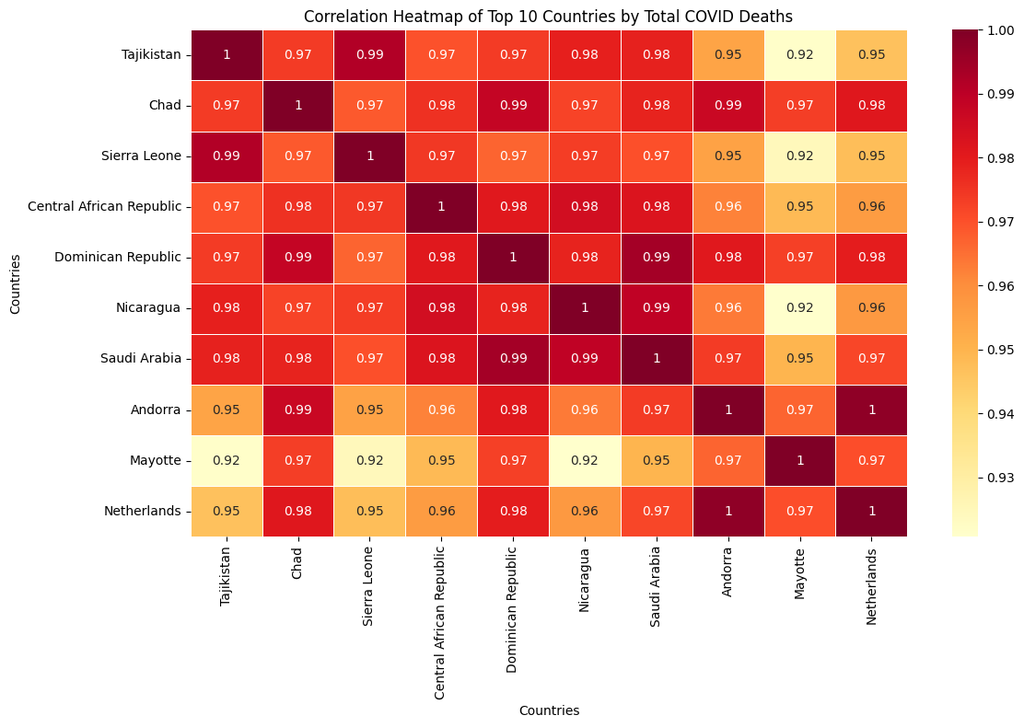

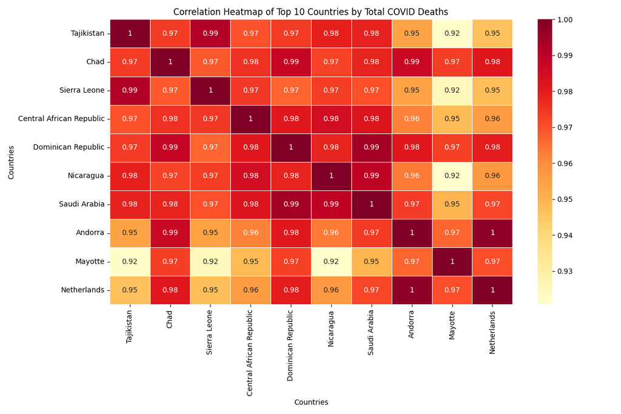

```python
print("Generating visualizations...")

print("\nVisualization 1. Calling to create correlation heatmap...")
create_correlation_heatmap(df)
```

```
Visualization 2. Calling to create bar chart...
Creating bar chart for top 20 countries...
```

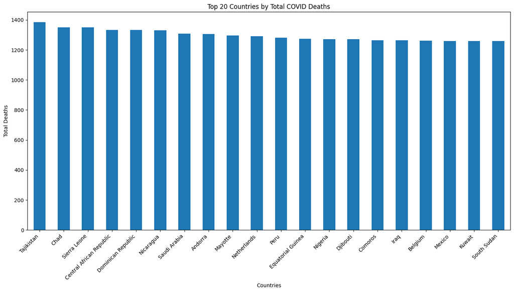

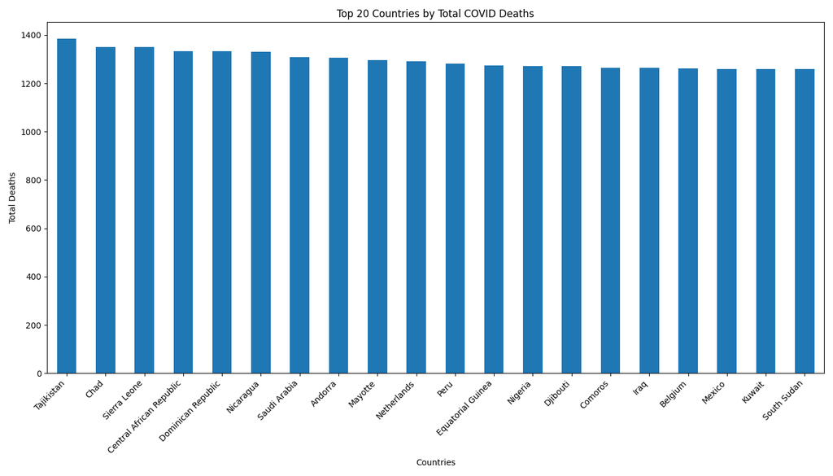

```python
print("Visualization 2. Calling to create bar chart...")
create_bar_chart(df)
```

```
Visualization 3. Calling to create time series chart...
Creating global time series chart...
```

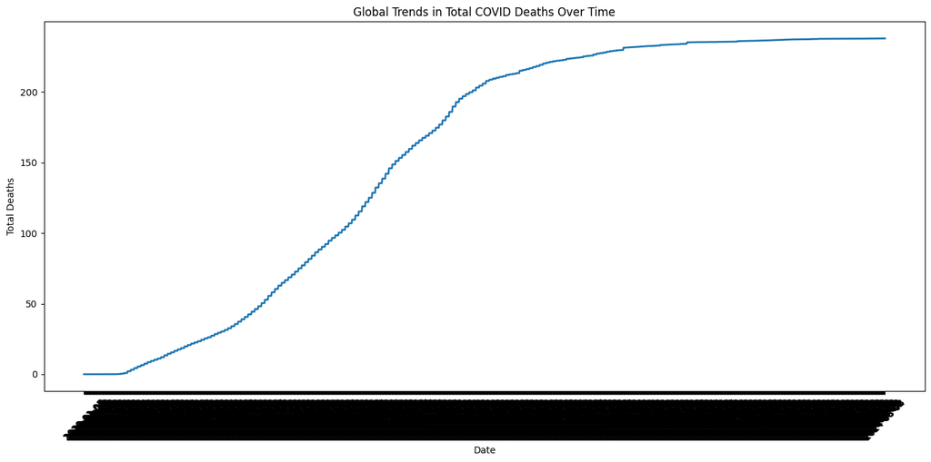

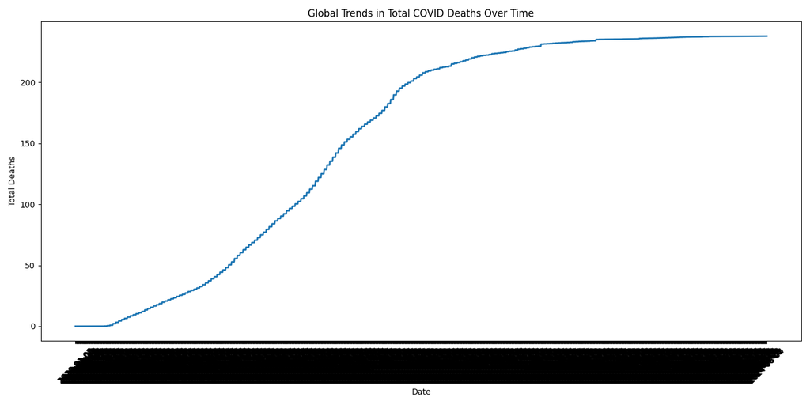

```
All visualizations have been generated, saved, and rendered.
```

```python
print("Visualization 3. Calling to create time series chart...")
create_time_series_chart(df)

print("\nAll visualizations have been generated, saved, and rendered.")
```

# Part Three: Interactive Visualizations

#### Use Plotly to create two interactive visualizations:

- One visualization should allow drill-down or zoom capabilities (e.g., zoom into specific time ranges or regions).
- Another should use Overview+Detail techniques (e.g., a main chart with a small overview window).

#### Add interactive elements, such as:

- Tooltips to display additional data on hover.
- Dropdown menus or buttons to filter data dynamically.

#### Expected Output

- **Drill-Down/Zoom Chart:** A line chart of global deaths with zooming and a range slider.
- **Overview+Detail Chart:** A combined chart with an overview (total deaths globally) and a detailed view (deaths for the top 5 countries).

*Note:* For the interactive visualizations, ensure that you use the **{variable}.show()** function to call the chart to render in the output so that it can be assessed in the html output.

## Load the preprocessed dataset from Part One above

```python
df = pd.read_csv("data/COVID_total_deaths_preprocessed.csv")
print("Preprocessed dataset loaded successfully!")
df.head()
```

```
Preprocessed dataset loaded successfully!
```

|  | date | World | Afghanistan | Africa | Albania | Algeria | American Samoa | Andorra | Angola | Anguilla | ... | Uruguay | Uzbekistan | Vanuatu | Vatican | Venezuela | Vietnam | Wallis and Futuna | Yemen | Zambia | Zimbabwe |
| --- | --- | --- | --- | --- | --- | --- | --- | --- | --- | --- | --- | --- | --- | --- | --- | --- | --- | --- | --- | --- | --- |
| 0 | 2020-01-05 | 0.0 | 0.0 | 0.0 | 0.0 | 0.0 | 0.0 | 0.0 | 0.0 | 0.0 | ... | 0.0 | 0.0 | 0.0 | 0.0 | 0.0 | 0.0 | 0.0 | 0.0 | 0.0 | 0.0 |
| 1 | 2020-01-06 | 0.0 | 0.0 | 0.0 | 0.0 | 0.0 | 0.0 | 0.0 | 0.0 | 0.0 | ... | 0.0 | 0.0 | 0.0 | 0.0 | 0.0 | 0.0 | 0.0 | 0.0 | 0.0 | 0.0 |
| 2 | 2020-01-07 | 0.0 | 0.0 | 0.0 | 0.0 | 0.0 | 0.0 | 0.0 | 0.0 | 0.0 | ... | 0.0 | 0.0 | 0.0 | 0.0 | 0.0 | 0.0 | 0.0 | 0.0 | 0.0 | 0.0 |
| 3 | 2020-01-08 | 0.0 | 0.0 | 0.0 | 0.0 | 0.0 | 0.0 | 0.0 | 0.0 | 0.0 | ... | 0.0 | 0.0 | 0.0 | 0.0 | 0.0 | 0.0 | 0.0 | 0.0 | 0.0 | 0.0 |
| 4 | 2020-01-09 | 0.0 | 0.0 | 0.0 | 0.0 | 0.0 | 0.0 | 0.0 | 0.0 | 0.0 | ... | 0.0 | 0.0 | 0.0 | 0.0 | 0.0 | 0.0 | 0.0 | 0.0 | 0.0 | 0.0 |

5 rows × 247 columns

## Preview the dataset

```python
print("Dataset Preview:")
df.head()
```

```
Dataset Preview:
```

|  | date | World | Afghanistan | Africa | Albania | Algeria | American Samoa | Andorra | Angola | Anguilla | ... | Uruguay | Uzbekistan | Vanuatu | Vatican | Venezuela | Vietnam | Wallis and Futuna | Yemen | Zambia | Zimbabwe |
| --- | --- | --- | --- | --- | --- | --- | --- | --- | --- | --- | --- | --- | --- | --- | --- | --- | --- | --- | --- | --- | --- |
| 0 | 2020-01-05 | 0.0 | 0.0 | 0.0 | 0.0 | 0.0 | 0.0 | 0.0 | 0.0 | 0.0 | ... | 0.0 | 0.0 | 0.0 | 0.0 | 0.0 | 0.0 | 0.0 | 0.0 | 0.0 | 0.0 |
| 1 | 2020-01-06 | 0.0 | 0.0 | 0.0 | 0.0 | 0.0 | 0.0 | 0.0 | 0.0 | 0.0 | ... | 0.0 | 0.0 | 0.0 | 0.0 | 0.0 | 0.0 | 0.0 | 0.0 | 0.0 | 0.0 |
| 2 | 2020-01-07 | 0.0 | 0.0 | 0.0 | 0.0 | 0.0 | 0.0 | 0.0 | 0.0 | 0.0 | ... | 0.0 | 0.0 | 0.0 | 0.0 | 0.0 | 0.0 | 0.0 | 0.0 | 0.0 | 0.0 |
| 3 | 2020-01-08 | 0.0 | 0.0 | 0.0 | 0.0 | 0.0 | 0.0 | 0.0 | 0.0 | 0.0 | ... | 0.0 | 0.0 | 0.0 | 0.0 | 0.0 | 0.0 | 0.0 | 0.0 | 0.0 | 0.0 |
| 4 | 2020-01-09 | 0.0 | 0.0 | 0.0 | 0.0 | 0.0 | 0.0 | 0.0 | 0.0 | 0.0 | ... | 0.0 | 0.0 | 0.0 | 0.0 | 0.0 | 0.0 | 0.0 | 0.0 | 0.0 | 0.0 |

5 rows × 247 columns

## Create Visualizations

### Visualization 1: Drill-Down/Zoom Capabilities

*Hints:* Use **show()** to render your interactive chart inside the notebook in an html exportable format.

```python
import plotly.express as px

def create_drill_down_chart(data):

    print("\nCreating drill-down/zoom visualization...")

    # Sum deaths globally by date
    global_deaths = data.drop(columns=['date']).sum(axis=1)

    # Create dataframe for plotting
    plot_data = pd.DataFrame({
        'date': data['date'],
        'global_deaths': global_deaths
    })

    # Interactive time series chart with zoom
    fig = px.line(
        plot_data,
        x='date',
        y='global_deaths',
        title='Global COVID-19 Total Deaths Over Time'
    )

    # Enable range slider / zoom
    fig.update_layout(
        xaxis_rangeslider_visible=True,
        template='plotly_white'
    )

    # Show chart
    fig.show()
```

### Visualization 2: Overview+Detail Chart

*Hints:* Use **show()** to render your interactive chart inside the notebook in an html exportable format.

```python
import plotly.graph_objects as go
from plotly.subplots import make_subplots

def create_overview_detail_chart(data):

    print("\nCreating overview+detail visualization...")

    # Aggregate totals and find top 5 countries
    country_totals = data.drop(columns=['date']).sum()
    top_5_countries = country_totals.nlargest(5).index

    # Filter dataset for top 5 countries
    top_5_data = data[['date'] + list(top_5_countries)]

    # Create overview + detail chart
    fig = make_subplots(
        rows=2,
        cols=1,
        shared_xaxes=True,
        vertical_spacing=0.08,
        row_heights=[0.25, 0.75]
    )

    # Overview portion (small chart)
    for country in top_5_countries:
        fig.add_trace(
            go.Scatter(
                x=top_5_data['date'],
                y=top_5_data[country],
                mode='lines',
                name=country,
                showlegend=False
            ),
            row=1,
            col=1
        )

    # Detail portion (main chart)
    for country in top_5_countries:
        fig.add_trace(
            go.Scatter(
                x=top_5_data['date'],
                y=top_5_data[country],
                mode='lines',
                name=country
            ),
            row=2,
            col=1
        )

    # Configure layout
    fig.update_layout(
        title='Overview + Detail of Top 5 Countries by Total COVID Deaths',
        height=700,
        template='plotly_white'
    )

    # Show chart
    fig.show()
```

## Call the visualization functions

*Reminder:* For the interactive visualizations, ensure that you use the **{variable}.show()** function to call the chart to render in the output so that it can be assessed in the html output.

```python
print("Generating visualizations...")

print("\nVisualization 1. Creating Drill-Down/Zoom Capabilities...")
create_drill_down_chart(df)
```

```
Generating visualizations...

Visualization 1. Creating Drill-Down/Zoom Capabilities...

Creating drill-down/zoom visualization...
```

[interactive chart not shown]

```python
print("Visualization 2. Creating Overview+Detail Chart...")
create_overview_detail_chart(df)

print("\nAll visualizations have been generated.")
```

```
Visualization 2. Creating Overview+Detail Chart...

Creating overview+detail visualization...
```

[interactive chart not shown]

```
All visualizations have been generated.
```

# Part Four: Customization and Animation

Using the original dataset `data/COVID_total_deaths.csv` (without normalization so as to ensure animation shows useful data points that are not scaled).

#### Customize the visualizations with matplotlib animation.

- A consistent theme or style (e.g., custom fonts, colors, gridlines).
- Layout optimization to ensure clarity and usability.

#### Add animation or transitions to one of the interactive visualizations

For example you can add animations to show changes over time (e.g., an animated line chart).

*Note:* For the interactive visualizations, ensure that you use the **{variable}.show()** function to call the chart to render in the output so that it can be assessed in the html output.

## Load the Dataset

```python
df = pd.read_csv("data/COVID_total_deaths.csv")
print("Original dataset loaded successfully!")
df.head()
```

```
Original dataset loaded successfully!
```

|  | date | World | Afghanistan | Africa | Albania | Algeria | American Samoa | Andorra | Angola | Anguilla | ... | Uruguay | Uzbekistan | Vanuatu | Vatican | Venezuela | Vietnam | Wallis and Futuna | Yemen | Zambia | Zimbabwe |
| --- | --- | --- | --- | --- | --- | --- | --- | --- | --- | --- | --- | --- | --- | --- | --- | --- | --- | --- | --- | --- | --- |
| 0 | 2020-01-05 | 3 | 0 | 0 | 0 | 0 | 0 | 0 | 0 | 0 | ... | 0 | 0 | 0 | 0 | 0 | 0 | 0 | 0 | 0 | 0 |
| 1 | 2020-01-06 | 3 | 0 | 0 | 0 | 0 | 0 | 0 | 0 | 0 | ... | 0 | 0 | 0 | 0 | 0 | 0 | 0 | 0 | 0 | 0 |
| 2 | 2020-01-07 | 3 | 0 | 0 | 0 | 0 | 0 | 0 | 0 | 0 | ... | 0 | 0 | 0 | 0 | 0 | 0 | 0 | 0 | 0 | 0 |
| 3 | 2020-01-08 | 3 | 0 | 0 | 0 | 0 | 0 | 0 | 0 | 0 | ... | 0 | 0 | 0 | 0 | 0 | 0 | 0 | 0 | 0 | 0 |
| 4 | 2020-01-09 | 3 | 0 | 0 | 0 | 0 | 0 | 0 | 0 | 0 | ... | 0 | 0 | 0 | 0 | 0 | 0 | 0 | 0 | 0 | 0 |

5 rows × 247 columns

## Clean and Preprocess the Data

```python
def clean_data(data):
    print("\nCleaning the dataset...")

    # Remove countries with all zero deaths
    data = data.loc[:, (data.drop(columns=['date']) != 0).any(axis=0).tolist() + [True]]

    # Remove rows (dates) with all zero deaths
    data = data[(data.drop(columns=['date']).sum(axis=1) != 0)]

    # Convert 'date' column to datetime
    data['date'] = pd.to_datetime(data['date'])

    # Display filtered dataset shape
    print("Filtered dataset shape:", data.shape)

    return data
```

```python
df_clean = clean_data(df)
```

```
Cleaning the dataset...
Filtered dataset shape: (1674, 239)
```

## Select Top 10 Countries

```python
def select_top_countries(data):
    print("\nSelecting top 10 countries by total deaths...")

    # Calculate total deaths by country
    country_totals = data.drop(columns=['date']).sum()

    # Exclude aggregate regions/groups
    exclude_regions = [
        "World",
        "Africa",
        "Europe",
        "North America",
        "South America",
        "Asia",
        "European Union (27)",
        "High-income countries",
        "Upper-middle-income countries",
        "Lower-middle-income countries"
    ]

    country_totals = country_totals.drop(
        labels=[col for col in exclude_regions if col in country_totals.index],
        errors='ignore'
    )

    # Select top 10 individual countries
    top_10_countries = country_totals.nlargest(10).index

    print("\nTop 10 individual countries by total deaths:")
    print(top_10_countries)

    # Filter dataset for top 10 countries
    filtered_data = data[['date'] + list(top_10_countries)]

    # Aggregate weekly (downsample)
    filtered_data = filtered_data.set_index('date').resample('W').sum().reset_index()

    print(f"\nFiltered dataset shape after selecting: {filtered_data.shape}")

    return filtered_data
```

```python
top_countries_data = select_top_countries(df_clean)
```

```
Selecting top 10 countries by total deaths...

Top 10 individual countries by total deaths:
Index(['United States', 'Brazil', 'India', 'Russia', 'Mexico', 'Peru',
       'United Kingdom', 'Italy', 'France', 'Germany'],
      dtype='object')

Filtered dataset shape after selecting: (240, 11)
```

## Prepare Data for Animation

```python
print("Preparing data for animation...")

# Melt the data for easier plotting
animated_data = top_countries_data.melt(
    id_vars='date',
    var_name='Country',
    value_name='Total Deaths'
)

print(animated_data.head())
```

```
Preparing data for animation...
        date        Country  Total Deaths
0 2020-01-05  United States             0
1 2020-01-12  United States             0
2 2020-01-19  United States             0
3 2020-01-26  United States             0
4 2020-02-02  United States             0
```

```python
print("Data prepared successfully!")
print(animated_data.head())
```

```
Data prepared successfully!
        date        Country  Total Deaths
0 2020-01-05  United States             0
1 2020-01-12  United States             0
2 2020-01-19  United States             0
3 2020-01-26  United States             0
4 2020-02-02  United States             0
```

## Create the Matplotlib Animation

```
Creating the animation... ignore static output
```

[figure not shown]

```python
print("Creating the animation... ignore static output")
# Initialize the plot
fig, ax = plt.subplots(figsize=(14, 8))

# Set axis limits and labels
ax.set_xlim(0, animated_data["Total Deaths"].max() * 1.1)
ax.set_ylim(-0.5, 9.5)

ax.set_xlabel("Total Deaths")
ax.set_ylabel("Country")
ax.set_title("Top 10 Countries by COVID-19 Total Deaths Over Time")
```

```python
# Create one line object for each country
lines = []
countries = animated_data['Country'].unique()

for i, country in enumerate(countries):
    line, = ax.plot([], [], marker='o', linestyle='', label=country)
    lines.append(line)

ax.legend(loc='upper right', bbox_to_anchor=(1.25, 1))
```

### Function to initialize the animation

```python
def init():
    # Initialize all line values
    for line in lines:
        line.set_data([], [])
    return lines
```

### Function to update the animation frame-by-frame

```python
def update(frame):
    current_date = animated_data['date'].unique()[frame]
    frame_data = animated_data[animated_data['date'] == current_date]

    for i, country in enumerate(frame_data['Country'].unique()):
        country_data = frame_data[frame_data['Country'] == country]
        lines[i].set_data(country_data['Total Deaths'], [i])

    ax.set_title(f"Top 10 Countries by COVID-19 Total Deaths\n{current_date.strftime('%Y-%m-%d')}")

    return lines
```

### Create the animation

*Hints:* Use **FuncAnimation()** to initate the animation visualization. Use **HTML({variable}.to_jshtml())** to render your animation inside the notebook in an html exportable format.

```python
# Create the animation
from IPython.display import HTML
ani = FuncAnimation(
    fig,
    update,
    frames=len(animated_data['date'].unique()),
    init_func=init,
    interval=200,
    blit=True
)

# Show the animation
HTML(ani.to_jshtml())
```

[figure not shown]